# Kendall’s Tau

```r
library(ggplot2)
library(microbenchmark)
library(Rcpp)
library(reshape2)
library(Kendall)
```

## Introduction

**Kendall’s Tau** est un estimateur non paramétrique de la corrélation entre deux ensembles de variables aléatoires, $X$ et $Y$, défini comme suit :

$$\tau(X, Y) = \text{P}\left\{ (X - X^*)(Y - Y^*) > 0 \right\} -
\text{P}\left\{ (X - X^*)(Y - Y^*) < 0 \right\}$$

Où $(X^*, Y^*)$ est une copie indépendante de $(X, Y)$.

L’algorithme traditionnel de calcul de cette statistique est donné par (Press, Flannery, Teukolsky, Vetterling, 1993):

$$\tau = \frac{C - D}{\sqrt{(C + D + T_1)(C + D + T_2)}}$$

Où : - $C$ est le nombre de **concordances**, - $D$ est le nombre de **discordances**, - $T_1$ et $T_2$ sont les nombres de **liaisons** dans les deux séries.

Les définitions des termes sont les suivantes :

- **Concordant (c)** : Un couple $(i, j)$ est concordant si $(X_i - X_j)(Y_i - Y_j) > 0$. Cela signifie que les rangs relatifs de $X$ et $Y$ sont dans le même ordre pour les deux observations.
- **Discordant (d)** : Un couple $(i, j)$ est discordant si $(X_i - X_j)(Y_i - Y_j) < 0$. Cela signifie que les rangs relatifs de $X$ et $Y$ sont dans un ordre opposé pour les deux observations.
- **Liaison T1 (T_1)** : Un couple $(i, j)$ est une liaison $T_1$ si $X_i = X_j$ et $Y_i \neq Y_j$. Cela signifie que les valeurs de $X$ sont égales, mais les valeurs de $Y$ sont différentes.
- **Liaison T2 (T_2)** : Un couple $(i, j)$ est une liaison $T_2$ si $X_i \neq X_j$ et $Y_i = Y_j$. Cela signifie que les valeurs de $Y$ sont égales, mais les valeurs de $X$ sont différentes.
- **Spare** : Un couple $(i, j)$ est un spare si $X_i = X_j$ et $Y_i = Y_j$. Cela signifie que les valeurs des deux séries sont égales pour les deux observations.

Le problème de cet algorithme naïf est qu’il a une complexité temporelle en $O(n^2)$, car il y a $\frac{n(n-1)}{2}$ comparaisons à effectuer.

Un algorithme amélioré pour le calcul du Tau de Kendall est l’algorithme **NDTau**. Cet algorithme repose sur l’utilisation d’un jeu de données sans doublons, que l’on trie ensuite avec un algorithme de tri ayant une complexité de $O(n \log n)$. Dans notre cas, nous avons choisi d’utiliser un **tri fusion**.

Lorsque l’on travaille avec un jeu de données sans doublons, les valeurs de $T_1$ et $T_2$ sont égales à zéro. En effet, comme il n’y a pas de valeurs égales, il n’y a pas de liaisons. De plus, étant donné que la somme des concordances et discordances $C + D$ est égale à $\frac{n(n-1)}{2}$, on obtient une expression simplifiée pour Tau :

$$\tau = 1 - \frac{4D}{n(n-1)}$$

où $D$ est le nombre de discordances.

## Génération des données synthétiques

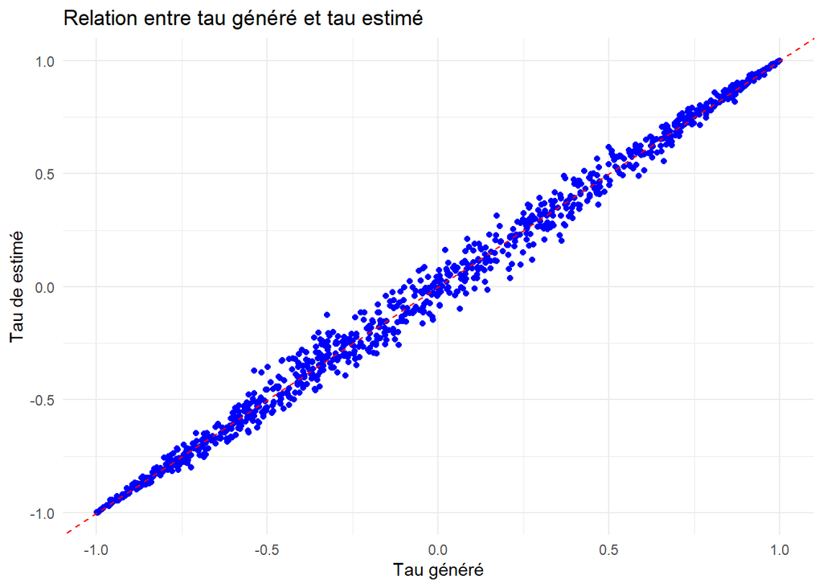

```r
# Fonction pour générer des données synthétiques

generate_correlated_data <- function(n = 100) {

  # Génère un tau de Kendall aléatoire entre -1 et 1
  tau <- runif(1, -1, 1)

  # Approximation de la corrélation de Pearson à partir du tau de Kendall
  rho <- sin(tau * pi / 2)

  # Génére deux variables normales standard indépendantes
  X <- rnorm(n)
  Z <- rnorm(n)

  # Construit Y avec la corrélation rho
  Y <- rho * X + sqrt(1 - rho^2) * Z

  return(list(X = X, Y = Y, tau = tau, rho = rho))
}

# Tests
results <- data.frame(tau = numeric(), kendall_tau = numeric())
for (i in 1:1000) {
  data <- generate_correlated_data(100)
  kendall_tau <- cor(data$X, data$Y, method = "kendall")
  results <- rbind(results, data.frame(tau = data$tau, kendall_tau = kendall_tau))
}

ggplot(results, aes(x = tau, y = kendall_tau)) +
  geom_point(color = "blue") +
  geom_abline(slope = 1, intercept = 0, linetype = "dashed", color = "red") +
  labs(title = "Relation entre tau généré et tau estimé",
       x = "Tau généré",
       y = "Tau de estimé") +
  theme_minimal()
```

```r
# Fonction pour calculer la corrélation de Kendall sur un échantillon bootstrap

bootstrap_kendall <- function(x, y, n_bootstrap) {
  tau_bootstrap <- numeric(n_bootstrap)

  for (i in 1:n_bootstrap) {
    # Rééchantillonnage avec remplacement
    sample_indices <- sample(1:length(x), length(x), replace = TRUE)
    x_sample <- x[sample_indices]
    y_sample <- y[sample_indices]

    # Calcul de la corrélation de Kendall pour le rééchantillon
    tau_bootstrap[i] <- cor(x_sample, y_sample, method = "kendall")
  }

  # Retourne les résultats bootstrap (moyenne et intervalle de confiance)
  return(c(mean = mean(tau_bootstrap),
           lower = quantile(tau_bootstrap, 0.025),
           upper = quantile(tau_bootstrap, 0.975)))
}
```

```r
# Test des fonctions avec différentes tailles d'échantillons

N_values <- seq(100, 2001, by=50)
n_bootstrap <- 100
results <- data.frame()

for (N in N_values) {
  data <- generate_correlated_data(N)
  x <- data$X
  y <- data$Y

  # Calcul des tau
  tau_R_naif <- naive_tau_kendall_R(x, y)
  tau_R_ND <- NDtau_kendall_R(x, y)
  tau_cpp_naif <- naive_tau_kendall_cpp(x, y)
  tau_cpp_ND <- NDtau_kendall_cpp(x, y)

  # Estimation par bootstrap
  bootstrap_result <- bootstrap_kendall(x, y, n_bootstrap)

  # Benchmark
  bench <- microbenchmark(
    R_naif = naive_tau_kendall_R(x, y),
    R_ND = NDtau_kendall_R(x, y),
    cpp_naif = naive_tau_kendall_cpp(x, y),
    cpp_ND = NDtau_kendall_cpp(x, y),
    times = 5  # Répéter 5 fois pour réduire la variance
  )

  # Extrait les temps de chaque méthode depuis le benchmark
  time_R_naif <- median(bench$time[bench$expr == "R_naif"]) / 1e6
  time_R_ND <- median(bench$time[bench$expr == "R_ND"]) / 1e6
  time_cpp_naif <- median(bench$time[bench$expr == "cpp_naif"]) / 1e6
  time_cpp_ND <- median(bench$time[bench$expr == "cpp_ND"]) / 1e6

  # Stocke les résultats dans un dataframe
  temp <- data.frame(
    N = N,
    Time_R_naif = time_R_naif,
    Time_R_ND = time_R_ND,
    Time_cpp_naif = time_cpp_naif,
    Time_cpp_ND = time_cpp_ND,
    Tau_R_naif = tau_R_naif,
    Tau_R_ND = tau_R_ND,
    Tau_cpp_naif = tau_cpp_naif,
    Tau_cpp_ND = tau_cpp_ND,
    Tau_Bootstrap_mean = bootstrap_result[1],
    Tau_Bootstrap_lower = bootstrap_result[2],
    Tau_Bootstrap_upper = bootstrap_result[3]
  )

  # Ajoute les résultats à la dataframe globale
  results <- rbind(results, temp)
}

print(head(results))
```

```
##         N Time_R_naif Time_R_ND Time_cpp_naif Time_cpp_ND  Tau_R_naif
## mean  100      0.7771    0.5832        0.0147      0.0102 -0.40929293
## mean1 150      1.7033    0.9673        0.0445      0.0228 -0.57941834
## mean2 200      3.0580    1.4190        0.1059      0.0393  0.42291457
## mean3 250      4.3743    1.4140        0.0474      0.0231  0.99575904
## mean4 300      6.5127    1.9974        0.2807      0.0383  0.21645485
## mean5 350      9.1345    2.2831        0.4078      0.0598 -0.03066721
##          Tau_R_ND Tau_cpp_naif  Tau_cpp_ND Tau_Bootstrap_mean
## mean  -0.40929293  -0.40929293 -0.40929293        -0.41842432
## mean1 -0.57941834  -0.57941834 -0.57941834        -0.57745484
## mean2  0.42291457   0.42291457  0.42291457         0.42138190
## mean3  0.99575904   0.99575904  0.99575904         0.99578919
## mean4  0.21645485   0.21645485  0.21645485         0.21131547
## mean5 -0.03066721  -0.03066721 -0.03066721        -0.03367717
##       Tau_Bootstrap_lower Tau_Bootstrap_upper
## mean           -0.5091640         -0.29034973
## mean1          -0.6321734         -0.52101060
## mean2           0.3510463          0.48515960
## mean3           0.9937316          0.99719486
## mean4           0.1445083          0.26908841
## mean5          -0.1140523          0.03418144
```

## Vérification des Tau

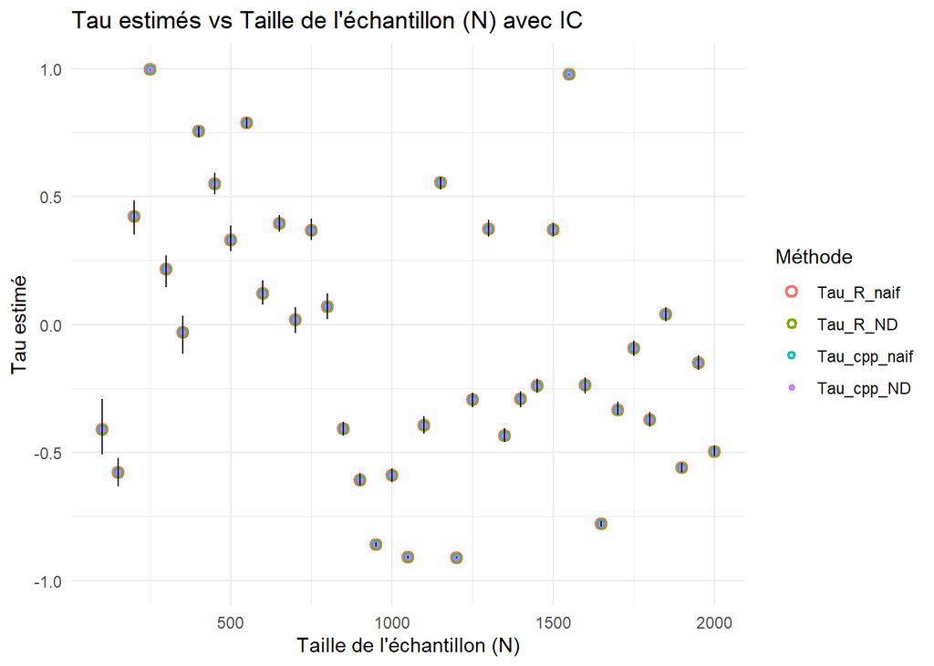

```r
# Vérification des Tau calculés

plot_tau_vs_bootstrap_with_ci <- function(results) {

  # Transforme les données pour un format long compatible avec ggplot2
  results_long <- melt(results, id.vars = c("N", "Tau_Bootstrap_mean", "Tau_Bootstrap_lower", "Tau_Bootstrap_upper"),
                       measure.vars = c("Tau_R_naif", "Tau_R_ND", "Tau_cpp_naif", "Tau_cpp_ND"),
                       variable.name = "Method", value.name = "Tau")

  # Défini des tailles différentes de points pour chaque méthode
  size_mapping <- c("Tau_R_naif" = 2, "Tau_R_ND" = 1.5, "Tau_cpp_naif" = 1, "Tau_cpp_ND" = 0.5)

  # Trace les tau estimés en fonction de N avec les intervalles de confiance
  ggplot(results_long, aes(x = N, y = Tau, color = Method)) +
    geom_point(aes(size = Method), shape = 1, stroke = 1.2) +  # Cercles vides avec tailles différentes
    geom_errorbar(aes(ymin = Tau_Bootstrap_lower, ymax = Tau_Bootstrap_upper),
                  width = 0.01, alpha = 0.4, color = "black") +
    scale_y_continuous(limits = c(-1, 1)) +
    scale_size_manual(values = size_mapping) +
    labs(title = "Tau estimés vs Taille de l'échantillon (N) avec IC",
         x = "Taille de l'échantillon (N)",
         y = "Tau estimé",
         color = "Méthode",
         size = "Méthode") +
    theme_minimal()
}

plot_tau_vs_bootstrap_with_ci(results)
```

## Comparatif

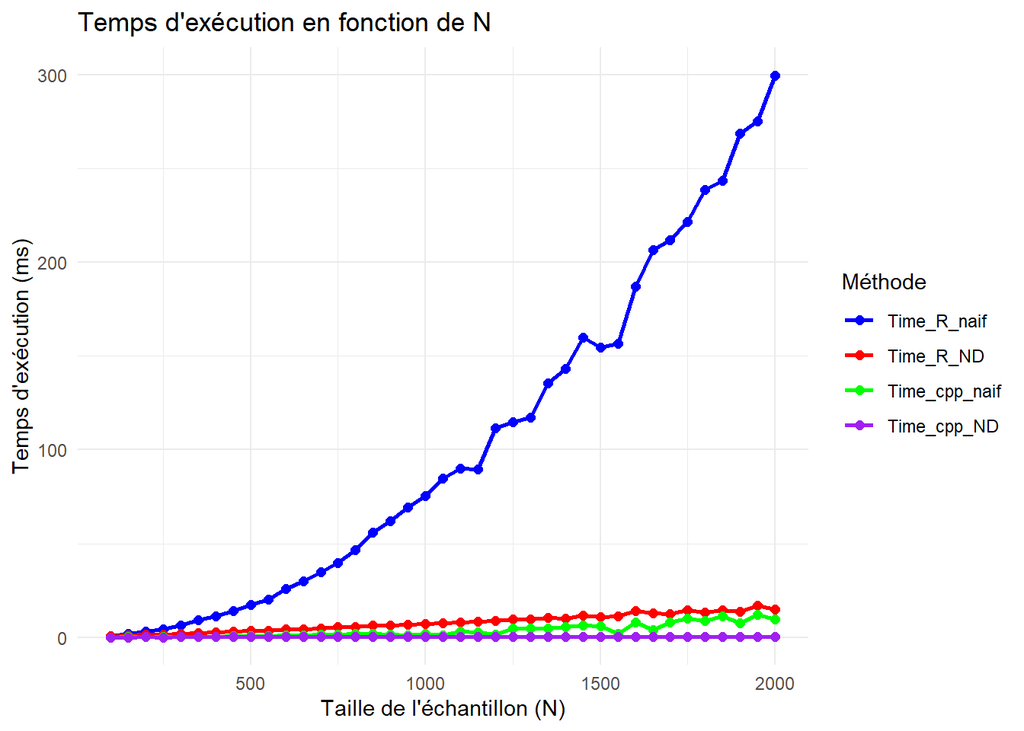

```r
# Comparatif simple des temps des différentes méthodes
plot_execution_times <- function(results) {

  # Transforme les données pour un format long compatible avec ggplot2
  results_long <- reshape2::melt(results, id.vars = "N",
                                 measure.vars = c("Time_R_naif", "Time_R_ND", "Time_cpp_naif", "Time_cpp_ND"),
                                 variable.name = "Method", value.name = "Time")

  # Trace les temps d'exécution en fonction de N
  ggplot(results_long, aes(x = N, y = Time, color = Method)) +
    geom_line(size = 1) +
    geom_point(size = 2) +
    labs(title = "Temps d'exécution en fonction de N",
         x = "Taille de l'échantillon (N)",
         y = "Temps d'exécution (ms)",
         color = "Méthode") +
    theme_minimal() +
    scale_color_manual(values = c("Time_R_naif" = "blue", "Time_R_ND" = "red",
                                  "Time_cpp_naif" = "green", "Time_cpp_ND" = "purple"))
}

plot_execution_times(results)
```

## Ratio R vs Rcpp

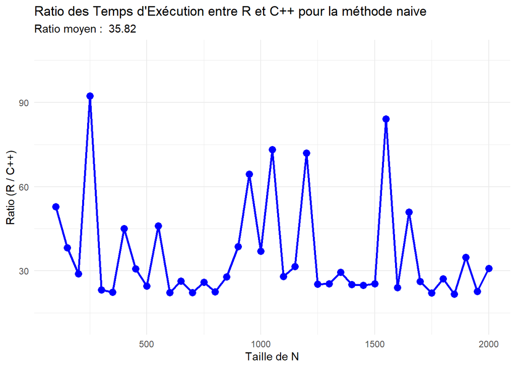

```r
# Analyse du ratio entre R et C++ pour la méthode naive

results$Ratio_naif <- results$Time_R_naif / results$Time_cpp_naif

# Trace le ratio entre R et C++ pour la méthode naive
ggplot(results, aes(x = N, y = Ratio_naif)) +
  geom_point(color = "blue", size = 3) +
  geom_line(color = "blue", size = 1) +
    scale_y_continuous(limits = c(mean(results$Ratio_naif)/3, mean(results$Ratio_naif)*3)) +
  labs(title = "Ratio des Temps d'Exécution entre R et C++ pour la méthode naive",
       x = "Taille de N",
       y = "Ratio (R / C++)",
       subtitle = paste("Ratio moyen : ", round(mean(results$Ratio_naif), 2))) +
  theme_minimal()
```

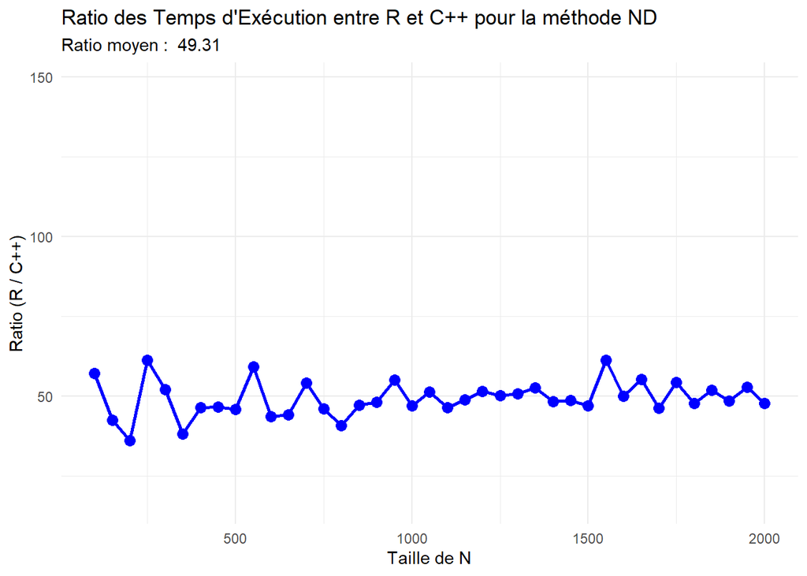

```r
# Analyse du ratio entre R et C++ pour la méthode ND

results$Ratio_ND <- results$Time_R_ND / results$Time_cpp_ND

# Trace le ratio entre R et C++ pour la méthode ND
ggplot(results, aes(x = N, y = Ratio_ND)) +
  geom_point(color = "blue", size = 3) +
  geom_line(color = "blue", size = 1) +
    scale_y_continuous(limits = c(mean(results$Ratio_ND)/3, mean(results$Ratio_ND)*3)) +
  labs(title = "Ratio des Temps d'Exécution entre R et C++ pour la méthode ND",
       x = "Taille de N",
       y = "Ratio (R / C++)",
       subtitle = paste("Ratio moyen : ", round(mean(results$Ratio_ND), 2))) +
  theme_minimal()
```

## Analyse de la compléxité

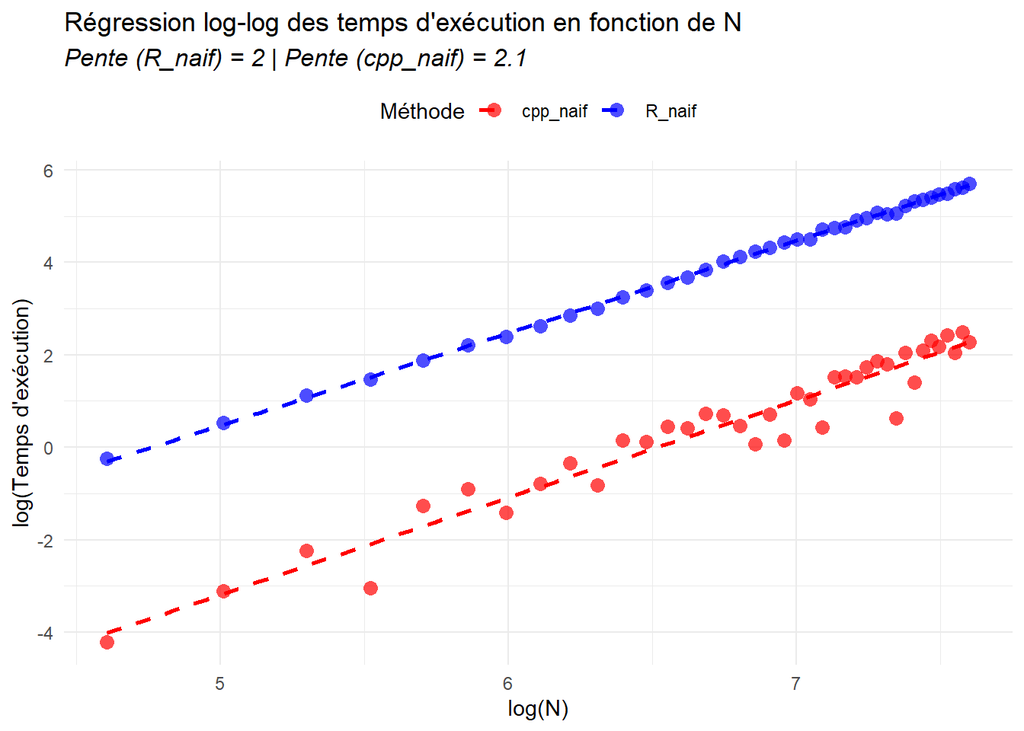

```r
# Régression de la complexité temporelle de l'approche naïve

# Calcul des logarithmes nécessaires
results$log_N <- log(results$N)
results$log_Time_R_naif <- log(results$Time_R_naif)
results$log_Time_cpp_naif <- log(results$Time_cpp_naif)

# Régressions log-log pour obtenir les pentes
lm_R_naif <- lm(log_Time_R_naif ~ log_N, data = results)
lm_cpp_naif <- lm(log_Time_cpp_naif ~ log_N, data = results)

# Extraction des pentes
pente_R_naif <- coef(lm_R_naif)[2]
pente_cpp_naif <- coef(lm_cpp_naif)[2]

# Graphique
ggplot(results, aes(x = log_N)) +
  geom_point(aes(y = log_Time_R_naif, color = "R_naif"), size = 3, shape = 16, alpha = 0.7) +
  geom_point(aes(y = log_Time_cpp_naif, color = "cpp_naif"), size = 3, shape = 16, alpha = 0.7) +
  geom_smooth(aes(y = log_Time_R_naif, color = "R_naif"), method = "lm", se = FALSE, size = 1, linetype = "dashed") +
  geom_smooth(aes(y = log_Time_cpp_naif, color = "cpp_naif"), method = "lm", se = FALSE, size = 1, linetype = "dashed") +
  labs(
    title = "Régression log-log des temps d'exécution en fonction de N",
    subtitle = paste("Pente (R_naif) =", round(pente_R_naif, 2), "| Pente (cpp_naif) =", round(pente_cpp_naif, 2)),
    x = "log(N)",
    y = "log(Temps d'exécution)",
    color = "Méthode"
  ) +
  scale_color_manual(values = c("R_naif" = "blue", "cpp_naif" = "red")) +
  theme_minimal() +
  theme(legend.position = "top", plot.subtitle = element_text(size = 12, face = "italic"))
```

```r
# Pour la méthode naïve, on retrouve bien la complexité attendue en O(n^2)
```

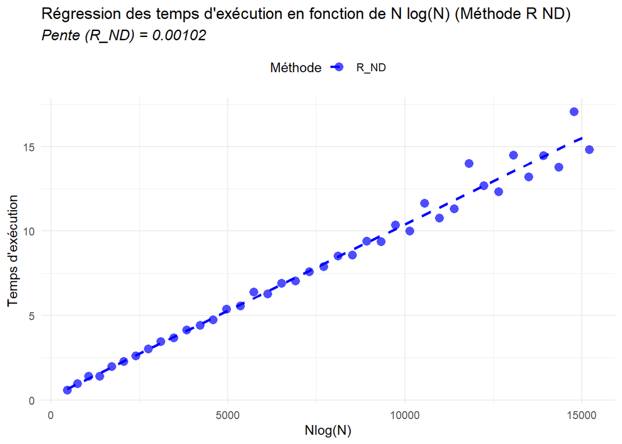

```r
# Régression de la complexité temporelle de l'approche R ND

# Calcul des logarithmes nécessaires
results$Nlog_N <- results$N * log(results$N)
results$log_Time_R_ND <- (results$Time_R_ND)

# Régression log-log pour obtenir la pente
lm_R_ND <- lm(log_Time_R_ND ~ Nlog_N, data = results)
pente_R_ND <- coef(lm_R_ND)[2]

# Graphique
ggplot(results, aes(x = Nlog_N)) +
  geom_point(aes(y = log_Time_R_ND, color = "R_ND"), size = 3, shape = 16, alpha = 0.7) +
  geom_smooth(aes(y = log_Time_R_ND, color = "R_ND"), method = "lm", se = FALSE, size = 1, linetype = "dashed") +
  labs(title = "Régression des temps d'exécution en fonction de N log(N) (Méthode R ND)",
       subtitle = paste("Pente (R_ND) =", round(pente_R_ND, 5)),
       x = "Nlog(N)",
       y = "Temps d'exécution",
       color = "Méthode") +
  scale_color_manual(values = c("R_ND" = "blue")) +
  theme_minimal() +
  theme(legend.position = "top", plot.subtitle = element_text(size = 12, face = "italic"))
```

```r
# Pour la méthode R NDTau, on retrouve aussi la complexité attendue en nlog(n)
```

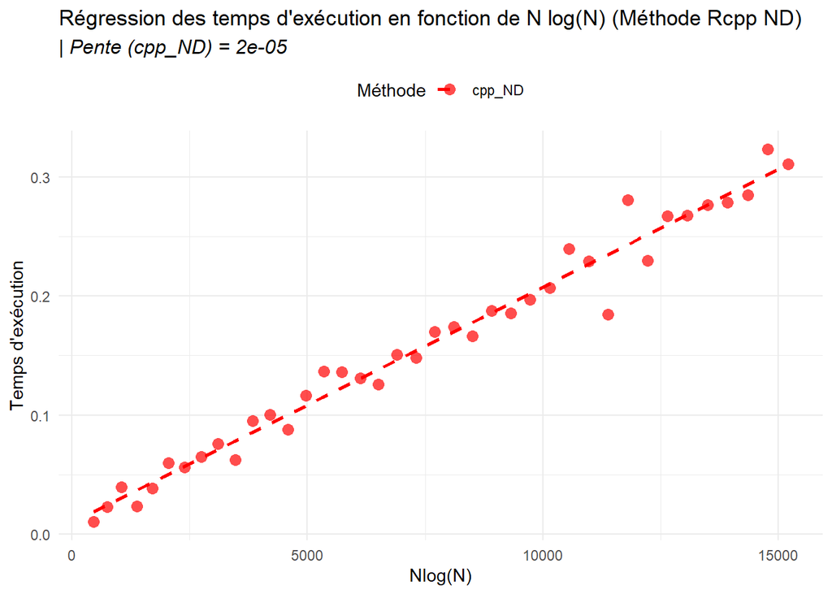

```r
# Régression de la complexité temporelle de l'approche Rcpp ND

# Calcul des logarithmes nécessaires
results$Nlog_N <- results$N*log(results$N)
results$log_Time_cpp_ND <- (results$Time_cpp_ND)


# Régression log-log pour obtenir la pente
lm_cpp_ND <- lm(log_Time_cpp_ND ~ Nlog_N, data = results)
pente_cpp_ND <- coef(lm_cpp_ND)[2]

# Graphique
ggplot(results, aes(x = Nlog_N)) +
  geom_point(aes(y = log_Time_cpp_ND, color = "cpp_ND"), size = 3, shape = 16, alpha = 0.7) +
  geom_smooth(aes(y = log_Time_cpp_ND, color = "cpp_ND"), method = "lm", se = FALSE, size = 1, linetype = "dashed") +
  labs(
    title = "Régression des temps d'exécution en fonction de N log(N) (Méthode Rcpp ND)",
    subtitle = paste("| Pente (cpp_ND) =", round(pente_cpp_ND, 5)),
    x = "Nlog(N)",
    y = "Temps d'exécution",
    color = "Méthode"
  ) +
  scale_color_manual(values = c( "cpp_ND" = "red")) +
  theme_minimal() +
  theme(legend.position = "top", plot.subtitle = element_text(size = 12, face = "italic"))
```

```r
# Pour la méthode Rcpp NDTau, on retrouve aussi la complexité attendue en nlog(n)
```

## Analyse en temps limité

```r
# Calcul du N maximum par méthode pour un temps limite fixé de 10 secondes
find_max_N_power_test <- function(time_limit_sec, base = 10, exp_min = 6, exp_max = 10) {
  start_time <- Sys.time()

  # Fonctions à tester
  methods <- list(
    "Tau_R_naif" = naive_tau_kendall_R,
    "Tau_R_ND" = NDtau_kendall_R,
    "Tau_cpp_naif" = naive_tau_kendall_cpp,
    "Tau_cpp_ND" = NDtau_kendall_cpp
  )

  # Liste pour stocker le N_max pour chaque méthode
  max_N_for_methods <- numeric(length(methods))
  names(max_N_for_methods) <- names(methods)

  # Boucle sur chaque méthode
  for (method in names(methods)) {
    func <- methods[[method]]

    max_N_for_method <- 0  # Variable pour stocker le plus grand N testé sous le temps limite

    # Tester les puissances de N
    for (exp in seq(exp_min, exp_max, by = 1)) {
      N_test <- base^exp
      data <- generate_correlated_data(N_test)

      # Mesurer le temps d'exécution
      exec_time_sec <- microbenchmark(func(data$X, data$Y), times = 1)$time / 1e9  # Convertir en secondes

      # Ajouter le résultat si le temps est sous le temps limite
      if (exec_time_sec > time_limit_sec) {
        break  # Arrêter dès que le temps dépasse
      }

      # Mettre à jour le plus grand N pour cette méthode
      max_N_for_method <- N_test
    }

    # Stocker le N_max pour la méthode
    max_N_for_methods[method] <- max_N_for_method
  }

  # Créer un data frame avec les résultats sous forme de ligne
  N_results <- as.data.frame(t(max_N_for_methods))
  colnames(N_results) <- names(methods)

  end_time <- Sys.time()  # Fin du chronomètre
  total_exec_time_min <- as.numeric(difftime(end_time, start_time, units = "mins"))  # Temps total en minutes
  cat("\nTemps total d'exécution de la fonction:", round(total_exec_time_min,0), "minutes\n")

  return(N_results)
}

time_limit_sec = 10
max_N_test_results <- find_max_N_power_test(time_limit_sec = time_limit_sec, base = 2, exp_min = 10, exp_max = 30)
```

```
##
## Temps total d'exécution de la fonction: 2 minutes
```

```r
print(max_N_test_results)
```

```
##   Tau_R_naif Tau_R_ND Tau_cpp_naif Tau_cpp_ND
## 1       8192   524288        32768   16777216
```

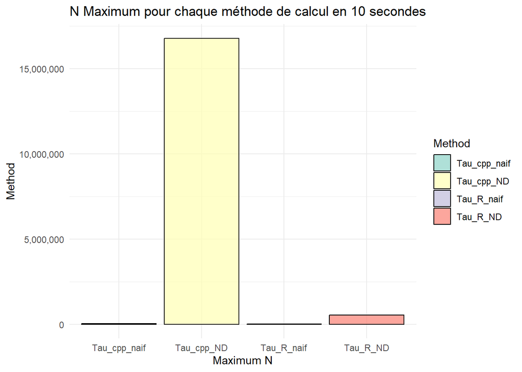

```r
# Plot
max_N_values <- as.numeric(max_N_test_results[1,])
method_names <- names(max_N_test_results)
plot_data <- data.frame(Method = method_names, MaxN = max_N_values)
ggplot(plot_data, aes(x = Method, y = MaxN, fill = Method)) +
  geom_bar(stat = "identity", color = 'black', alpha = 0.7) +
  scale_y_continuous(labels = scales::comma) +
  labs(title = paste("N Maximum pour chaque méthode de calcul en", time_limit_sec, "secondes"),
       x = "Maximum N",
       y = "Method") +
  theme_minimal() +
  scale_fill_brewer(palette = "Set3")
```